# Time, Success, and Catastrophe

- Show All Code
- Hide All Code
- View Source

Author

Matthew Huang

```r
library(tidyverse)
everest <- read_csv("everest-1.csv")
```

### 0.1 Introduction

This report seeks to explore the trends of Mount Everest expeditions’ durations and success rates, with a spotlight on the dramatic events of 2014 and 2015. Our analysis is conducted using the Everest dataset, which covers over 2000 Mount Everest ascents from 1953 to 2020.

```r
# Mutating the dataset to accomodate our analysis
everest <- everest |>
  # changing dates to date types
  mutate(basecamp_date = mdy(basecamp_date),
         termination_date = mdy(termination_date),
         highpoint_date = mdy(highpoint_date)) |>
  # creating an expedition duration variable (2 methods)
  mutate(duration = if_else(!is.na(termination_date),
                            termination_date - basecamp_date,
                            highpoint_date - basecamp_date)) |>
  # duration type variable
  mutate(duration_type = case_when(!is.na(termination_date) ~ 'full',
                                   !is.na(highpoint_date) ~ 'partial',
                                   TRUE ~ 'missing'))

everest_plot <- everest |>
  # filter to focus the plot on denser area
  filter(year >= 1960, duration<=100) |>
  # success variable for grouping
  mutate(success_indicator = if_else(str_detect(termination_reason, "[Ss]uccess"), 1, 0))
```

**Note**

Expedition duration is calculated via days between the base camp and termination date (when available). Due to there being a significant number of missing termination dates, missing terminal dates were supplemented with highpoint dates, so expedition durations in the analysis are underestimated.

The following plot aims to capture the trends in expedition times, along with the distribution of successes, over the years.

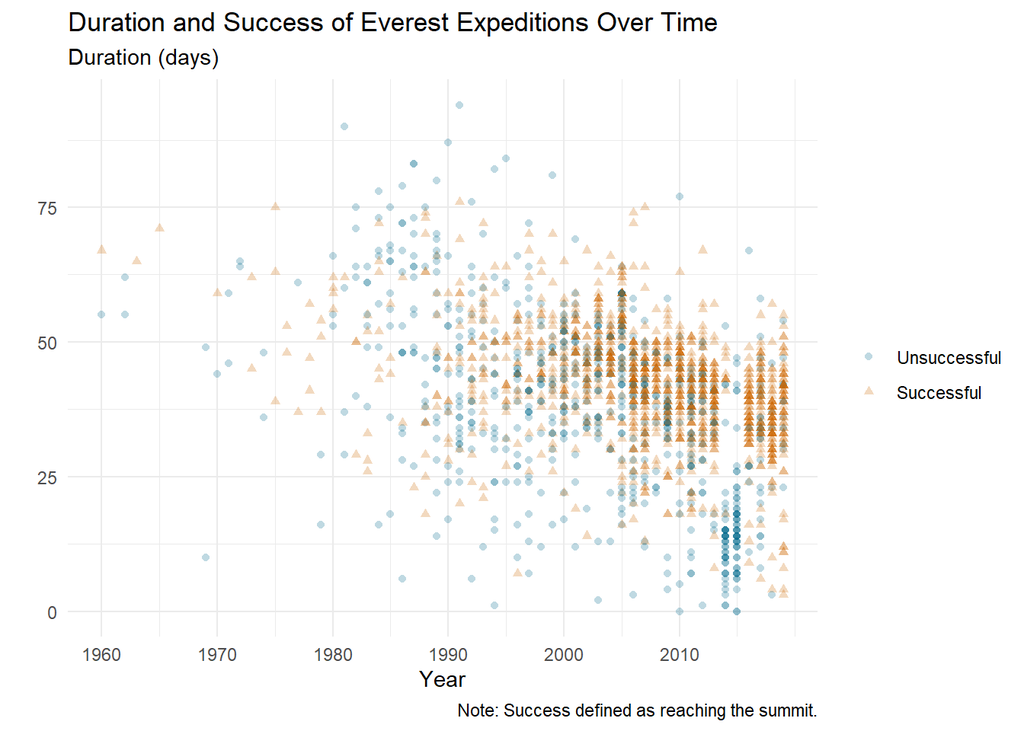

```r
everest_plot |>
  ggplot(aes(x = year, y = duration,
             color = as.factor(success_indicator),
             shape = as.factor(success_indicator))) +
    geom_point(alpha=0.25) +
    scale_color_manual(values = c("0" = "deepskyblue4", "1" = "darkorange3"),
                       labels = c("Unsuccessful", "Successful")) +
    scale_shape_manual(values = c(16, 17),
                       labels = c("Unsuccessful", "Successful")) +
    labs(color = "", shape="",
         title = "Duration and Success of Everest Expeditions Over Time",
         subtitle = "Duration (days)",
         x = "Year",
         y = "",
         caption = "Note: Success defined as reaching the summit.") +
    scale_x_continuous(breaks = seq(min(everest$year)-1, max(everest$year), by = 10))+
    theme_minimal()
```

There’s a clear convergence in expedition times, with a majority now spanning approximately one to two months (25-50 days). Additionally, there’s been a notable increase in expeditions’ success rates in recent years (ignoring notable exceptions).

Both these trends in consistency and success could potentially be attributed to improved weather forecasting methods, better training and equipment, the establishment of safe, well-known routes, and building of supporting infrastructure. These advances would enable more efficient planning as well as safer and more consistent ascension.

## 1 Notable Exceptions

```r
everest_plot |>
  filter(year >= 2010, duration<=100) |>
  group_by(year) |>
  summarize(total_fatalities = sum(member_deaths + hired_staff_deaths),
            fatality_percent = total_fatalities/sum(members + hired_staff)*100,
            total_expeditions = n(),
            success_rate = sum(success_indicator)/n())
```

```
# A tibble: 10 x 5
    year total_fatalities fatality_percent total_expeditions success_rate
   <dbl>            <dbl>            <dbl>             <int>        <dbl>
 1  2010                3            0.350                83        0.819
 2  2011                4            0.443                94        0.670
 3  2012                7            0.750                82        0.744
 4  2013                6            0.634                80        0.825
 5  2014               15            2.67                 53        0.189
 6  2015               13            1.64                 57        0
 7  2016                2            0.243                68        0.897
 8  2017                4            0.422                84        0.714
 9  2018                4            0.343                78        0.936
10  2019               10            0.930                79        0.873
```

## 2 What Happened in 2014-2015?

This period coincides with two major disasters:

- **2014 Ice Avalanche**: On April 18, 2014, a large ice avalanche caused by collapsing seracs (glacial columns) on Mount Everest’s western spur led to the death of sixteen climbing Sherpas in the Khumbu Icefall. This tragic event prompted many Sherpas (who make up the majority of hired guides) to cease work for the rest of the year in tribute.
- **2015 Earthquake**: The following year, a magnitude 7.8 earthquake struck Nepal on April 25, 2015. The earthquake triggered multiple large avalanches, one of which devastated the Everest Base Camp, resulting in at least twenty-two fatalities.

**Note**

Our data contains a total of only 15 fatalities in 2014 and 13 in 2015. These discrepancies suggest potential missing data, differing sources of death estimation, or possibly that deaths occurring at the base camp aren’t considered to happen during expedition.

The catastrophic events of 2014 and 2015 highlight the unpredictable dangers of scaling Mount Everest, even despite advancing technology and trends towards safety and consistency.